# HW3

Yasemin Gokdag

November 19, 2018

## Task1

### part a

Upload the data, and fix the column names, detailed code can be found on *Appendix*,

then select one instance from each class to plot , plots are as follows

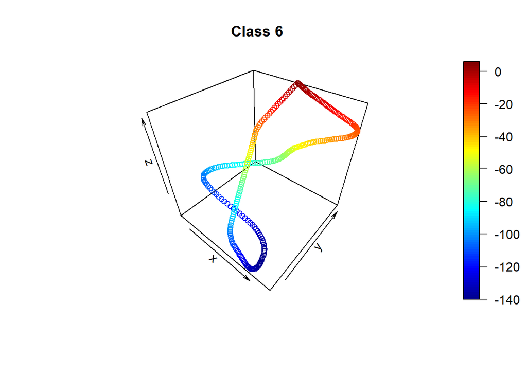

```r
#Get first row for each class variable
tx <- train_x[, .SD[1], by = Class]
ty <- train_y[, .SD[1], by = Class]
tz <- train_z[, .SD[1], by = Class]

points3D(cumsum(as.matrix(tx[1,])), cumsum(as.matrix(ty[1,])), cumsum(as.matrix(tz[1,])), type = 'p', main = paste0('Class ' , tx[1,]$Class))
```

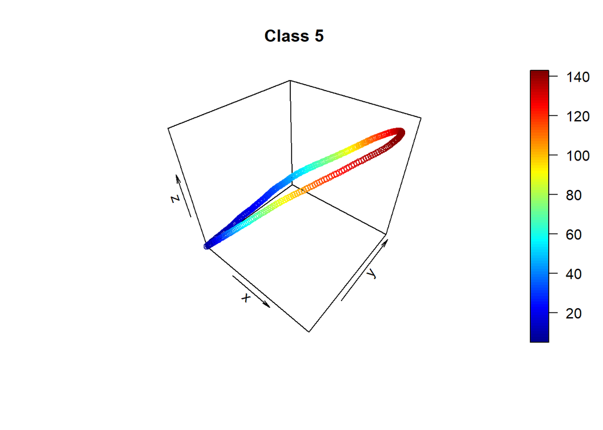

```r
points3D(cumsum(as.matrix(tx[2,])), cumsum(as.matrix(ty[2,])), cumsum(as.matrix(tz[2,])), type = 'p', main = paste0('Class ' , tx[2,]$Class))
```

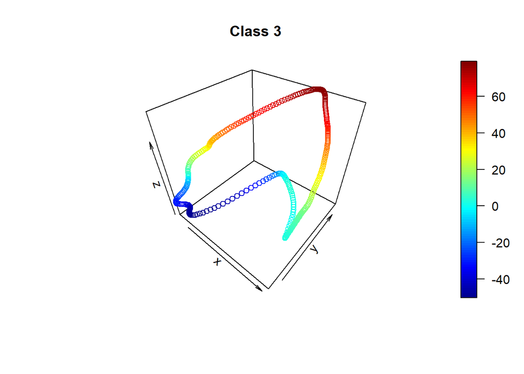

```r
points3D(cumsum(as.matrix(tx[3,])), cumsum(as.matrix(ty[3,])), cumsum(as.matrix(tz[3,])), type = 'p', main = paste0('Class ' , tx[3,]$Class))
```

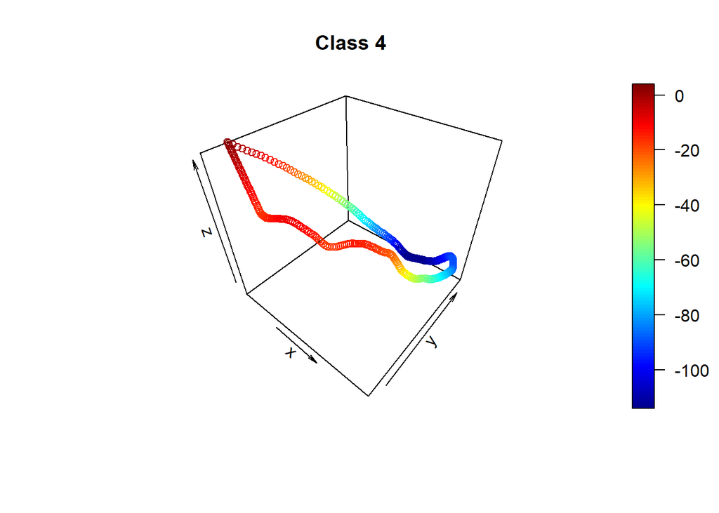

```r
points3D(cumsum(as.matrix(tx[4,])), cumsum(as.matrix(ty[4,])), cumsum(as.matrix(tz[4,])), type = 'p', main = paste0('Class ' , tx[4,]$Class))
```

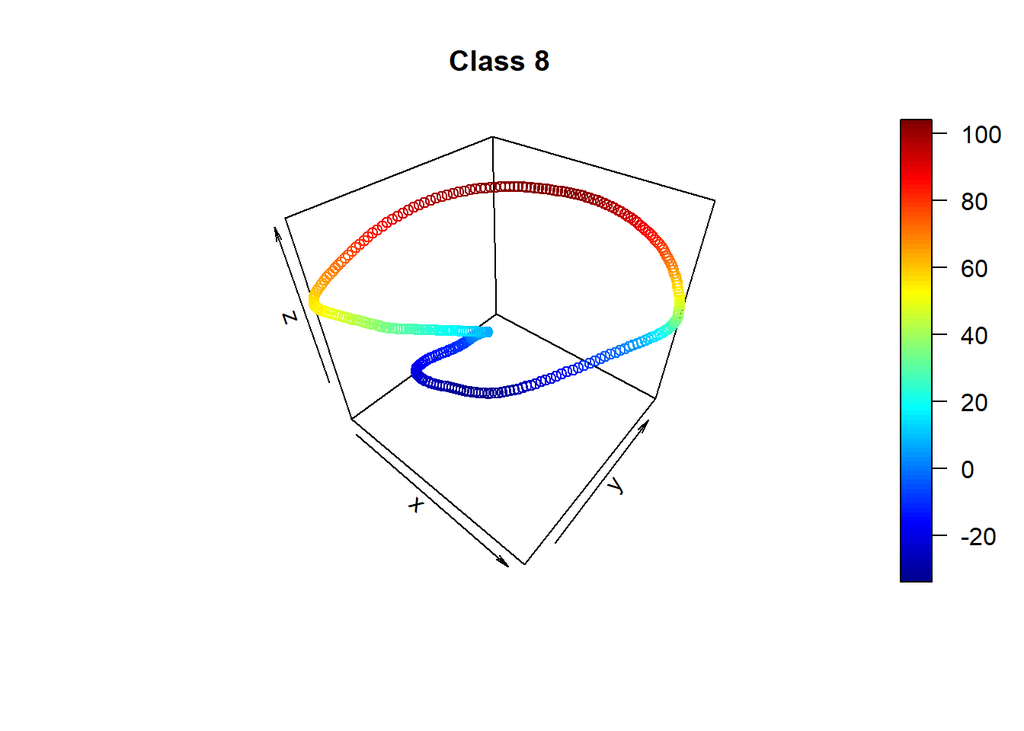

```r
points3D(cumsum(as.matrix(tx[5,])), cumsum(as.matrix(ty[5,])), cumsum(as.matrix(tz[5,])), type = 'p', main = paste0('Class ' , tx[5,]$Class))
```

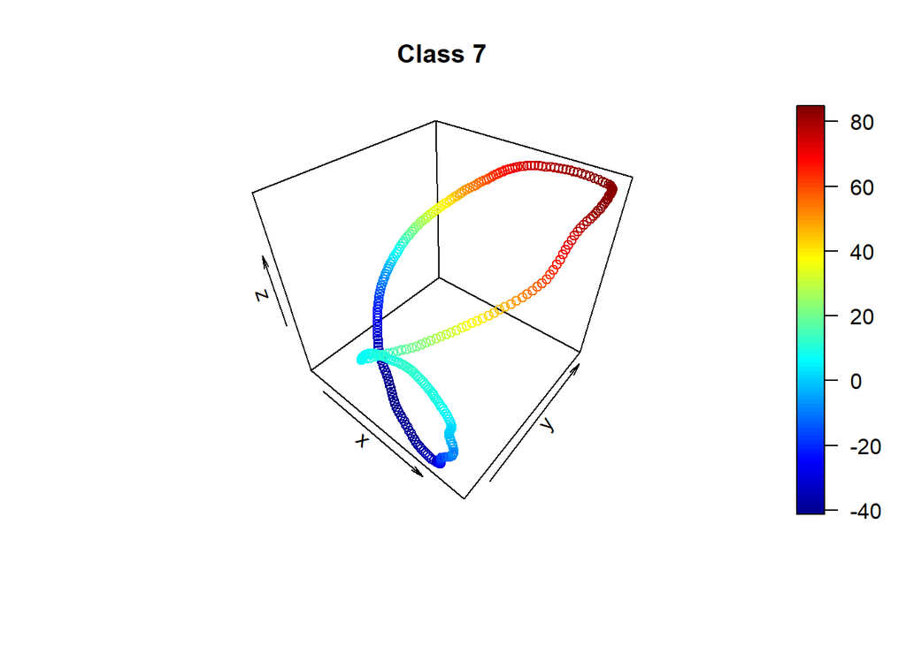

```r
points3D(cumsum(as.matrix(tx[6,])), cumsum(as.matrix(ty[6,])), cumsum(as.matrix(tz[6,])), type = 'p', main = paste0('Class ' , tx[6,]$Class))
```

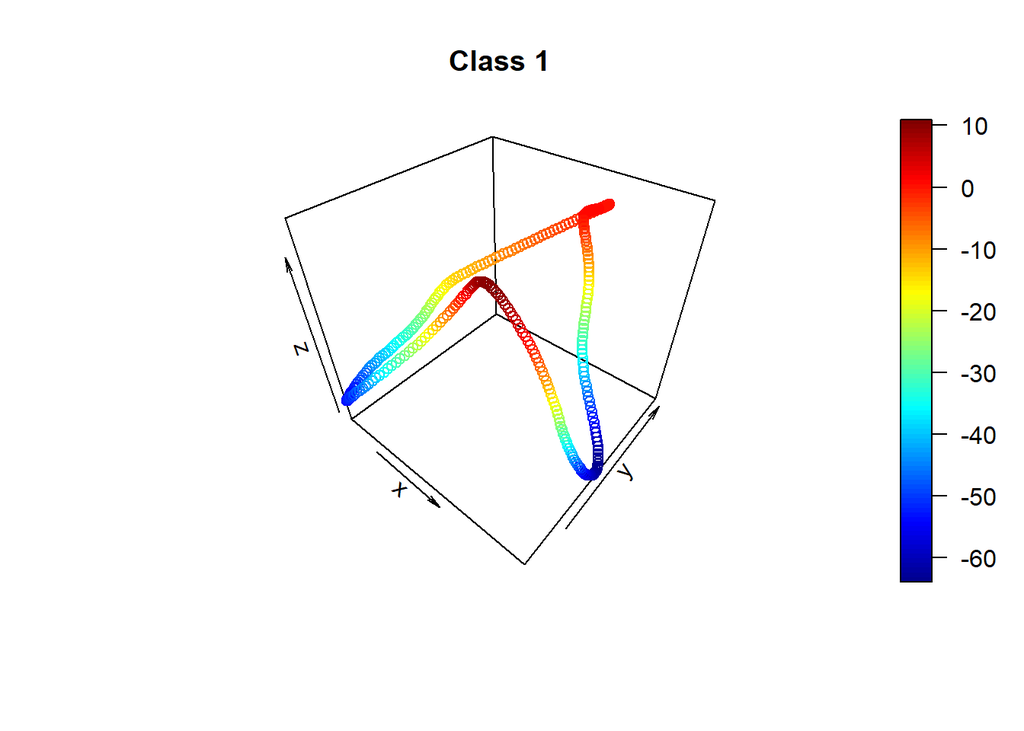

```r
points3D(cumsum(as.matrix(tx[7,])), cumsum(as.matrix(ty[7,])), cumsum(as.matrix(tz[7,])), type = 'p', main = paste0('Class ' , tx[7,]$Class))
```

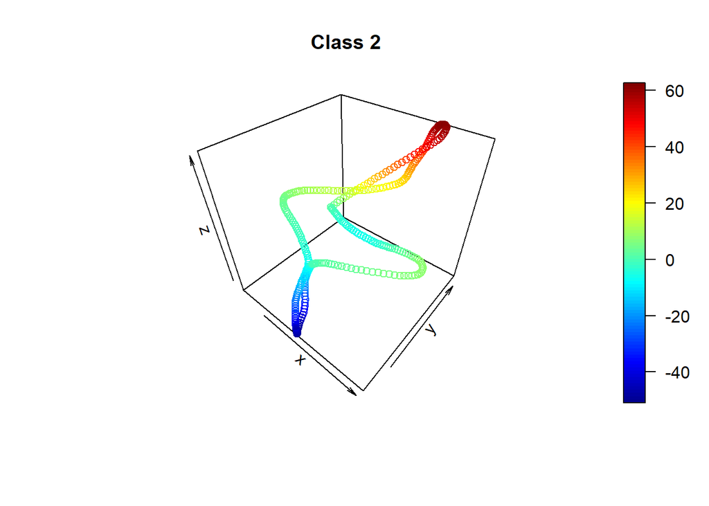

```r
points3D(cumsum(as.matrix(tx[8,])), cumsum(as.matrix(ty[8,])), cumsum(as.matrix(tz[8,])), type = 'p', main = paste0('Class ' , tx[8,]$Class))
```

### part b

For this part we are applying k-NN with 10-fold cross validation. I used euclidean distance and manhattan distance as distance measures.

Since we want each class to be represented by equal number of instances, we used stratification while obtaining folds for cross validation. Package ‘TunePareto’ was used for this part,

After we obtain indices, we fix them in order to be able to obtain a reasonable comparison. All k values for both distance uses the same indices.

Then we run the code for k values 1,2,3,4,5

Detailed codes can be found on *Appendix*

The results are as follows :

Euclidean distance k-NN accuracy matrix :

```
##     Fold Klev Observations Accuracy
##  1:    1    1           90       80
##  2:    1    2           90       80
##  3:    1    3           90       85
##  4:    1    4           90       85
##  5:    1    5           90       85
##  6:    2    1           90       82
##  7:    2    2           90       82
##  8:    2    3           90       84
##  9:    2    4           90       84
## 10:    2    5           90       82
## 11:    3    1           90       80
## 12:    3    2           90       80
## 13:    3    3           90       81
## 14:    3    4           90       81
```

[output cut: 37 more lines]

Manhattan distance k-NN accuracy matrix :

```
##     Fold Klev Observations Accuracy
##  1:    1    1           90       84
##  2:    1    2           90       84
##  3:    1    3           90       86
##  4:    1    4           90       86
##  5:    1    5           90       86
##  6:    2    1           90       83
##  7:    2    2           90       83
##  8:    2    3           90       85
##  9:    2    4           90       84
## 10:    2    5           90       84
## 11:    3    1           90       84
## 12:    3    2           90       84
## 13:    3    3           90       85
## 14:    3    4           90       83
```

[output cut: 37 more lines]

Euclidean distance k-NN error percentages :

```
##    Klev avg_error
## 1:    1 0.9207740
## 2:    2 0.9207740
## 3:    3 0.9240449
## 4:    4 0.9229338
## 5:    5 0.9162672
```

Manhattan distance k-NN error percentages :

```
##    Klev avg_error
## 1:    1 0.9375031
## 2:    2 0.9375031
## 3:    3 0.9452934
## 4:    4 0.9408489
## 5:    5 0.9330212
```

As seen on the results, k = 3 gives the best result for both distances

### part c

Confusion matrix for manhattan distance, 3 NN

```
##        actual.Class
## predict   1   2   3   4   5   6   7   8
##       1 431   1   2   3   3   5   0   0
##       2   0 451   0   0   0   0   0   0
##       3   0   0 417   0   4   4   5   0
##       4   3   0   0 384   2  15   0   1
##       5   0   0  13  48 423  25   0   1
##       6   3   0  18   8   1 400   0   0
##       7   0   0   4   0   0   0 442   0
##       8   0   0   0   7   0   0   0 458
```

Accuracy for manhattan distance, 3 NN

```
## [1] 0.9508654
```

Run time for manhattan distance, 3 NN

```
## Time difference of 48.25955 secs
```

Confusion matrix for euclidean distance, 3 NN

```
##        actual.Class
## predict   1   2   3   4   5   6   7   8
##       1 430   1   1   6   3   5   0   0
##       2   0 449   0   0   0   0   0   0
##       3   0   0 413   0   5   6   1   0
##       4   2   0   0 370   1  15   0   1
##       5   0   0  15  60 423  28   0   1
##       6   4   0  21   7   1 394   0   0
##       7   1   2   4   0   0   1 446   0
##       8   0   0   0   7   0   0   0 458
```

Accuracy for euclidean distance, 3 NN

```
## [1] 0.9444444
```

Run time for euclidean distance, 3 NN

```
## Time difference of 6.024927 secs
```

## Task2

### part a

For this task I used “penalized” package, and from this package I used optL2 function to deteremine lambda value. This is because the question states we should use fused lambda penalties, and the package describe lambda2 as penalty value on differences of the coefficients we also set fusedl parameter TRUE,

Then prediction for test data set is calculated. Detailed code can be found on *Appendix*

I applied 2 folds only, because it took too much time for my computer to evaluate the code. Ideally, we would perform it for 10 fold via assigning fold value to 10

Cofusion matrix for this part is as follows :

```
##        actual
## predict  0  1
##       0 25  7
##       1 11 57
```

Accuracy :

```
## [1] 0.82
```

### part b

summary is

```
## $lambda
## [1] 0.763932
##
## $cvl
## [1] -32.78451
##
## $predictions
##   [1] 0.30715904 0.88641132 0.27210550 0.36008940 0.86753059 0.92302800
##   [7] 0.24916731 0.83495535 0.94078798 0.90813355 0.67775151 0.61207811
##  [13] 0.35548752 0.95711819 0.13159052 0.96409088 0.94813994 0.95754603
##  [19] 0.44358933 0.23082921 0.95221499 0.84911883 0.95391844 0.18046886
##  [25] 0.93444487 0.45165496 0.89059256 0.07124687 0.95387155 0.95668914
##  [31] 0.94690841 0.95037731 0.91981900 0.95188246 0.97256658 0.24153857
##  [37] 0.71422799 0.92995856 0.71434004 0.94779442 0.41006905 0.38604303
##  [43] 0.91752770 0.10999487 0.49499847 0.97368820 0.76308983 0.10533739
##  [49] 0.96679077 0.30611707 0.89245079 0.92943684 0.87566355 0.56731693
##  [55] 0.95366155 0.93572097 0.03990232 0.15917189 0.91330262 0.94888069
##  [61] 0.96616239 0.28897485 0.39148373 0.95416648 0.90630521 0.35335513
##  [67] 0.86041075 0.85051041 0.96081165 0.92328754 0.43269119 0.97758800
##  [73] 0.98046732 0.94218089 0.95900703 0.88459707 0.98177561 0.94427755
##  [79] 0.96245801 0.43635211 0.77614010 0.63970961 0.94598929 0.63530452
##  [85] 0.14055820 0.26578338 0.19679134 0.96388491 0.72735150 0.89310621
##  [91] 0.07573958 0.90470544 0.90323364 0.43405799 0.87071746 0.24778854
##  [97] 0.39466416 0.78376426 0.95314526 0.94490253
##
## $fold
##   1   2   3   4   5   6   7   8   9  10  11  12  13  14  15  16  17  18
##   2   2   1   1   2   1   2   2   1   2   1   1   1   1   2   2   1   1
##  19  20  21  22  23  24  25  26  27  28  29  30  31  32  33  34  35  36
##   2   1   2   1   2   1   1   1   1   1   2   1   1   1   2   1   2   1
##  37  38  39  40  41  42  43  44  45  46  47  48  49  50  51  52  53  54
##   1   1   2   1   1   1   2   1   1   2   2   2   2   2   2   1   2   1
##  55  56  57  58  59  60  61  62  63  64  65  66  67  68  69  70  71  72
##   2   1   2   2   2   1   2   1   2   1   2   1   2   1   2   2   2   2
##  73  74  75  76  77  78  79  80  81  82  83  84  85  86  87  88  89  90
##   2   2   1   2   2   2   1   2   1   2   1   2   1   2   2   2   1   2
##  91  92  93  94  95  96  97  98  99 100
##   2   1   1   2   2   1   1   1   1   1
##
## $fullfit
## Penalized logistic regression object
## 96 regression coefficients of which 27 are non-zero
##
## Loglikelihood =   -24.82035
## L1 penalty =  6.417285   at lambda1 =  1
## L2 penalty =  2.337812   at lambda2 =  0.763932
```

### part c

We calcualte the difference as described in the task and do the same calculations, details can be found on *Appendix*

Confusion matrix is as follows

```
##        actual
## predict  0  1
##       0 25  4
##       1 11 60
```

Accuracy:

```
## [1] 0.85
```

### part d

We have higher accuracy, we directly use the difference between time points

Selected lambda value is:

```
## [1] 2
```

summary ’s :

```
## $lambda
## [1] 2
##
## $cvl
## [1] -50.34403
##
## $predictions
##   [1] 0.4173484 0.5772845 0.4558223 0.6188354 0.8545055 0.8424456 0.6966080
##   [8] 0.6349782 0.8804964 0.6794850 0.6362320 0.5294081 0.6987900 0.9229420
##  [15] 0.4263114 0.6371499 0.9181772 0.9142539 0.4411780 0.4819208 0.4492716
##  [22] 0.8021368 0.8256862 0.4460401 0.8541216 0.4372069 0.7363331 0.4259521
##  [29] 0.6843420 0.8905579 0.8976162 0.8876319 0.8582760 0.8264482 0.8504831
##  [36] 0.6451301 0.5765023 0.9080081 0.5140691 0.8793091 0.4948268 0.4092695
##  [43] 0.8768980 0.5815252 0.8052593 0.7732731 0.6454949 0.6157828 0.9004667
##  [50] 0.9159098 0.6922482 0.7129218 0.6367861 0.4983617 0.8465454 0.8650074
##  [57] 0.4176962 0.4098056 0.8781892 0.8818858 0.8465844 0.9154001 0.3942794
##  [64] 0.8047687 0.8040604 0.4169121 0.8580458 0.7560132 0.7419568 0.8454894
##  [71] 0.4932744 0.8825380 0.6704852 0.8790834 0.8901347 0.8345043 0.8935677
##  [78] 0.8969462 0.8117045 0.6909842 0.6411702 0.4321019 0.8531801 0.4592442
##  [85] 0.4448658 0.6773530 0.7505022 0.8727119 0.7050173 0.5771725 0.4848093
##  [92] 0.7705460 0.6997490 0.4689900 0.5750519 0.4041732 0.4171290 0.6003057
##  [99] 0.8803111 0.8610622
##
## $fold
##   1   2   3   4   5   6   7   8   9  10  11  12  13  14  15  16  17  18
##   1   2   1   2   2   1   2   2   2   1   2   2   2   2   1   1   2   2
##  19  20  21  22  23  24  25  26  27  28  29  30  31  32  33  34  35  36
##   1   1   2   1   1   1   1   1   1   1   1   2   1   1   2   2   2   2
##  37  38  39  40  41  42  43  44  45  46  47  48  49  50  51  52  53  54
##   1   2   1   2   1   1   1   2   2   2   1   2   2   2   1   1   1   1
##  55  56  57  58  59  60  61  62  63  64  65  66  67  68  69  70  71  72
##   2   2   1   2   2   2   2   2   1   2   2   2   1   1   1   1   1   1
##  73  74  75  76  77  78  79  80  81  82  83  84  85  86  87  88  89  90
##   2   1   2   2   1   2   2   2   1   1   1   2   2   2   2   2   1   1
##  91  92  93  94  95  96  97  98  99 100
##   2   1   2   1   1   1   1   1   1   2
##
## $fullfit
## Penalized logistic regression object
## 95 regression coefficients of which 16 are non-zero
##
## Loglikelihood =   -36.3391
## L1 penalty =  7.153444   at lambda1 =  1
## L2 penalty =  5.478321   at lambda2 =  2
```

# Appendix

Initialization :

```r
require(data.table)
require(knnGarden)
require(plot3D)
require(kknn)

train_x <- read.table(file = 'C:/Users/yasemin/Desktop/School/IE582/HWs/3/Train data/uWaveGestureLibrary_X_TRAIN', header =FALSE )
train_y <- read.table(file = 'C:/Users/yasemin/Desktop/School/IE582/HWs/3/Train data/uWaveGestureLibrary_Y_TRAIN', header =FALSE )
train_z <- read.table(file = 'C:/Users/yasemin/Desktop/School/IE582/HWs/3/Train data/uWaveGestureLibrary_Z_TRAIN', header =FALSE )

test_x <- read.table(file = 'C:/Users/yasemin/Desktop/School/IE582/HWs/3/Test data/uWaveGestureLibrary_X_TEST', header =FALSE )
test_y <- read.table(file = 'C:/Users/yasemin/Desktop/School/IE582/HWs/3/Test data/uWaveGestureLibrary_Y_TEST', header =FALSE )
test_z <- read.table(file = 'C:/Users/yasemin/Desktop/School/IE582/HWs/3/Test data/uWaveGestureLibrary_Z_TEST', header =FALSE )

train_x <- as.data.table(train_x)
train_y <- as.data.table(train_y)
train_z <- as.data.table(train_z)

num  <-  seq(1:315)
xnames <- paste('X.t', num, sep="", collapse = NULL)
xnames <- cbind("Class", t(xnames))

ynames <- paste('Y.t', num, sep="", collapse = NULL)
ynames <- cbind("Class", t(ynames))

znames <- paste('Z.t', num, sep="", collapse = NULL)
znames <- cbind("Class", t(znames))

#rm(znames)
setnames(train_x, xnames)
setnames(train_y, ynames)
setnames(train_z, znames)
```

```r
train_data <- cbind(train_x, train_y[,2:ncol(train_y)], train_z[,2:ncol(train_z)])
train_data <- as.data.table(train_data)

#Check counts per data
class_count <- train_data[, .(.N), by = .(Class)]

#We want to have equal number of data points from each class per fold (startification)
require(TunePareto)


#
k_levels=c(1,2,3,4,5)
thresHold=0.5
nofReplications=1
nFolds=10
indices=generateCVRuns(t(train_data[,1]),nofReplications,nFolds,stratified=TRUE)

cvresult=data.table()

for(i in 1:nFolds)
{
  testindices=indices[[1]][[i]]
  cvtrain=train_data[-testindices,]
  cvtest=train_data[testindices,]

  for(y in 1:length(k_levels)){
    param_k <- k_levels[y]
    predict <-  kknn(as.factor(Class) ~ .,
                     cvtrain,
                     cvtest,
                     k = param_k,
                     distance = 2,
                     kernel = "rectangular",
                     scale = FALSE)
    cvresult=rbind(cvresult,data.table(Fold=i,Method='knn',Klev=param_k,TestId = testindices,
                                       Predictions=predict$fitted.value,Real=cvtest[,1]))
    print(paste0('fold ', i, ' for k ', param_k, ' completed'))

  }
}

#Manhattan

manh_cvresult=data.table()
for(i in 1:nFolds)
{
  testindices=indices[[1]][[i]]
  cvtrain=train_data[-testindices,]
  cvtest=train_data[testindices,]

  for(y in 1:length(k_levels)){
    param_k <- k_levels[y]
    predict <-  kknn(as.factor(Class) ~ .,
                     cvtrain,
                     cvtest,
                          k = param_k,
                          distance = 1,
                     kernel = "rectangular",
                          scale = FALSE)
    manh_cvresult=rbind(manh_cvresult,data.table(Fold=i,Method='knn',Klev=param_k,TestId = testindices,
                                                 Predictions=predict$fitted.values,Real=cvtest[,1]))
    print(paste0('fold ', i, ' for k ', param_k, ' completed'))

  }
}
```

Task 2, part a function fit , prediction, confusion matrix calculation

```r
require(data.table)
ecgtrain <- read.table(file = 'C:/Users/yasemin/Desktop/School/IE582/HWs/3/ECG/NN_Classification/ecgTRAIN', header = FALSE  )
ecgtrain <- as.data.table(ecgtrain)

ecgtest <- read.table(file = 'C:/Users/yasemin/Desktop/School/IE582/HWs/3/ECG/NN_Classification/ecgTEST', header = FALSE  )
ecgtest <- as.data.table(ecgtest)

require(penalized)

response <- ecgtrain[,1]
response <- as.data.table(response)
response[V1 == -1, V1 := 0]
response <- as.matrix(response)

train <- ecgtrain[,2:ncol(ecgtrain)]

l2 <- optL2(response ,
      penalized = train,
      unpenalized = ~ 0,
      data = train,
      fusedl = T,
      standardize = T,
      lambda1 = 1 , minlambda2 = 0, maxlambda2 = 2,
      fold = 2,
      model = "logistic")

test <- ecgtest[,2:ncol(ecgtest)]

predict <- predict(object =  l2$fullfit, as.matrix(test))
predict <- as.data.table(predict)
predict[predict >= 0.5, predict := 1 ]
predict[predict < 0.5, predict := 0 ]

testclass <- ecgtest[,1]
testclass <- as.data.table(testclass)
testclass[V1 == -1, V1 := 0]
setnames(testclass, "actual")
testclass <- as.matrix(testclass)

error <- cbind(predict, testclass)
error <- as.data.table(error)

confusion <- table(error)
conf_accuracy <- sum(diag(confusion))/sum(confusion)
```

Task 2, part c function fit , prediction, confusion matrix calculation

```r
#Part-C

ecgtrain <- as.data.table(ecgtrain)
zeros <- matrix(data = 0 , ncol = 1 , nrow =nrow(ecgtrain))
subtract <- cbind(ecgtrain[,1], zeros,ecgtrain[,2:(ncol(ecgtrain)-1)])

difference <- ecgtrain[,2:ncol(ecgtrain)] - subtract[,2:ncol(subtract)]
difference <- cbind(ecgtrain[,1], difference[,2:ncol(difference)])

ecgtest <- as.data.table(ecgtest)
subtract_test <- cbind(ecgtest[,1], zeros,ecgtest[,2:(ncol(ecgtest)-1)])
difference_test <- ecgtest[,2:ncol(ecgtest)] - subtract_test[,2:ncol(subtract_test)]
difference_test <- cbind(ecgtest[,1], difference_test[,2:ncol(difference_test)])

response_d <- difference[,1]
response_d <- as.data.table(response_d)
response_d[V1 == -1, V1 := 0]
response_d <- as.matrix(response_d)

train_d <- difference[,2:ncol(difference)]

l2_d <- optL2(response_d ,
            penalized = train_d,
            unpenalized = ~ 0,
            data = train_d,
            fusedl = T,
            standardize = T,
            lambda1 = 1 , minlambda2 = 0, maxlambda2 = 2,
            fold = 2,
            model = "logistic")

test_d <- difference_test[,2:ncol(difference_test)]

predict_d <- predict(object =  l2_d$fullfit, as.matrix(test_d))
predict_d <- as.data.table(predict_d)

predict_d[predict_d >= 0.5, predict_d := 1 ]
predict_d[predict_d < 0.5, predict_d := 0 ]

test_d_class <- difference_test[,1]
test_d_class <- as.data.table(test_d_class)
test_d_class[V1 == -1, V1 := 0]
setnames(test_d_class, "actual")
test_d_class <- as.matrix(test_d_class)

setnames(predict_d, "predict")

error_d <- cbind(predict_d, test_d_class)
error_d <- as.data.table(error_d)

confusion_d <- table(error_d)
confd_accuracy <- sum(diag(confusion_d))/sum(confusion_d)
```